# ps5-rmarkdown-plot

2023-02-20

### Loading Data

```r
library(dplyr)
library(readr)

df <- read_delim("gapminder.csv.bz2")
# Rows and Columns
nrow(df)
```

```
## [1] 13055
```

```r
ncol(df)
```

```
## [1] 25
```

```r
# Small amount of samples
sample(df, 5)
```

```
## # A tibble: 13,055 × 5
##    fertilizerHa name  agricultureTractors youthFemaleLiteracy `sub-region`
##           <dbl> <chr>               <dbl>               <dbl> <chr>
##  1           NA Aruba                  NA                  NA Latin America and…
##  2           NA Aruba                  NA                  NA Latin America and…
##  3           NA Aruba                  NA                  NA Latin America and…
##  4           NA Aruba                  NA                  NA Latin America and…
##  5           NA Aruba                  NA                  NA Latin America and…
##  6           NA Aruba                  NA                  NA Latin America and…
##  7           NA Aruba                  NA                  NA Latin America and…
##  8           NA Aruba                  NA                  NA Latin America and…
##  9           NA Aruba                  NA                  NA Latin America and…
## 10           NA Aruba                  NA                  NA Latin America and…
## # … with 13,045 more rows
```

The data looks great! It just seems to have a majority of NA values which is an indicator that the data is incomplete in a sense.

### Descriptive Statistics

```r
n_distinct(df$iso3, na.rm = TRUE)
```

```
## [1] 253
```

```r
n_distinct(df$iso2, na.rm = TRUE)
```

```
## [1] 248
```

```r
n_distinct(df$name, na.rm = TRUE)
```

```
## [1] 249
```

There is a different count of unique countries, so that means there are some countries that are included in one set and not in the other data set.

2. 1. There are no countries that coorespond with multiple names.

```r
df %>%
  group_by(iso2) %>%
  summarise(num_names = n_distinct(name)) %>%
  arrange(desc(num_names))
```

```
## # A tibble: 249 × 2
##    iso2  num_names
##    <chr>     <int>
##  1 <NA>          2
##  2 AD            1
##  3 AE            1
##  4 AF            1
##  5 AG            1
##  6 AI            1
##  7 AL            1
##  8 AM            1
##  9 AO            1
## 10 AQ            1
## # … with 239 more rows
```

2. 2. There are no countries that coorespond with multiple names.

```r
df %>%
  group_by(iso3) %>%
  summarize(num_names = n_distinct(name)) %>%
  arrange(desc(num_names))
```

```
## # A tibble: 253 × 2
##    iso3  num_names
##    <chr>     <int>
##  1 ABW           1
##  2 AFG           1
##  3 AGO           1
##  4 AIA           1
##  5 ALA           1
##  6 ALB           1
##  7 AND           1
##  8 ARE           1
##  9 ARG           1
## 10 ARM           1
## # … with 243 more rows
```

```r
minmax_time <- df %>%
  filter(!is.na(time))%>%
  reframe(min=min(time), max=max(time))

minmax_time
```

```
## # A tibble: 1 × 2
##     min   max
##   <dbl> <dbl>
## 1  1960  2019
```

```r
# For Later
time_min <- minmax_time$min
time_max <- minmax_time$max
```

### CO2 Emissions

```r
df %>%
  filter(!is.na(time))%>%
  group_by(time) %>%
  summarize(co2_nullcount=sum(is.na(co2))) %>%
  arrange(desc(co2_nullcount)) %>%
  head(5)
```

```
## # A tibble: 5 × 2
##    time co2_nullcount
##   <dbl>         <int>
## 1  2017           217
## 2  2018           217
## 3  2019           217
## 4  1960            60
## 5  1961            60
```

```r
df %>%
  filter(!is.na(time))%>%
  group_by(time) %>%
  summarize(co2_PC_nullcount=sum(is.na(co2_PC))) %>%
  arrange(desc(co2_PC_nullcount)) %>%
  head(5)
```

```
## # A tibble: 5 × 2
##    time co2_PC_nullcount
##   <dbl>            <int>
## 1  2017              217
## 2  2018              217
## 3  2019              217
## 4  1960               60
## 5  1961               60
```

The years 2017 through 2019 are tied for most missing data, at 217 null count.

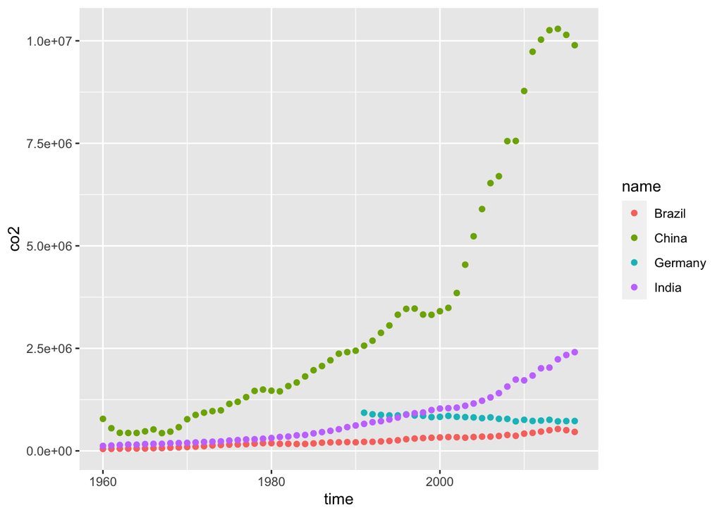

```r
library(ggplot2)

countries <- c("United States", "China", "India", "Russia", "Brazil", "Germany")

co2_data <- df %>%
  filter(name == countries[1] |
         name == countries[2] |
         name == countries[3] |
         name == countries[4] |
         name == countries[5] |
         name == countries[6],
         !is.na(co2))

ggplot(co2_data, aes(x = time, y = co2, color=name)) +
  geom_point()
```

I see China has had a large increase in CO2 emissions since 1960 and has hit an apparent local maximum around 2015. I also noticed the US and Russia do not have data being plotted.

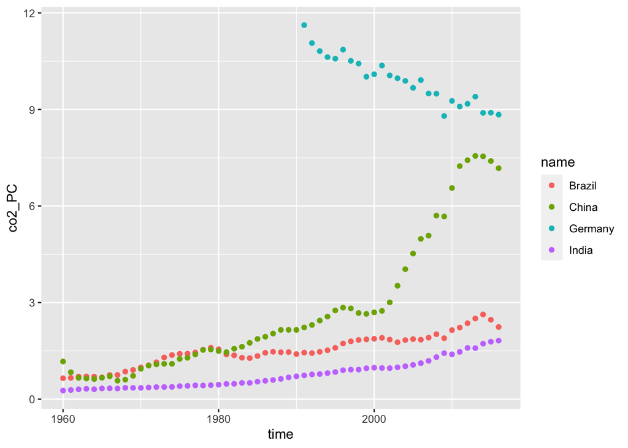

```r
library(ggplot2)

countries <- c("United States", "China", "India", "Russia", "Brazil", "Germany")

co2_data <- df %>%
  filter(name == countries[1] |
         name == countries[2] |
         name == countries[3] |
         name == countries[4] |
         name == countries[5] |
         name == countries[6],
         !is.na(co2_PC))

ggplot(co2_data, aes(x = time, y = co2_PC, color=name)) +
  geom_point()
```

I still see that China has had a large increase in CO2 emissions per capita in the time period, but I can now also see that Brazil and India had a consistent increase in CO2 emissions per capita during that time as well, and since recording data, Germany has decreased their CO2 emissions per capita. This figure is more effective becasue it measures CO2 emissions per capita, which is a better indicator of overall efficiency.

```r
avg_region_co2_PC <- df %>%
  filter(!is.na(region),
         !is.na(time),
         !is.na(co2_PC)) %>%
  group_by(region, time) %>%
  summarize(co2_PC_mean=mean(co2_PC)) %>%
  arrange(region)
avg_region_co2_PC
```

```
## # A tibble: 285 × 3
## # Groups:   region [5]
##    region  time co2_PC_mean
##    <chr>  <dbl>       <dbl>
##  1 Africa  1960       0.291
##  2 Africa  1961       0.300
##  3 Africa  1962       0.299
##  4 Africa  1963       0.310
##  5 Africa  1964       0.349
##  6 Africa  1965       0.385
##  7 Africa  1966       0.422
##  8 Africa  1967       0.607
##  9 Africa  1968       0.781
## 10 Africa  1969       0.824
## # … with 275 more rows
```

I see Americas is 4.8018156, and I also see that the table is hard to read because I have to manually scroll to a specific region and time to see the co2 average. I also see that there is nothing after 2016.

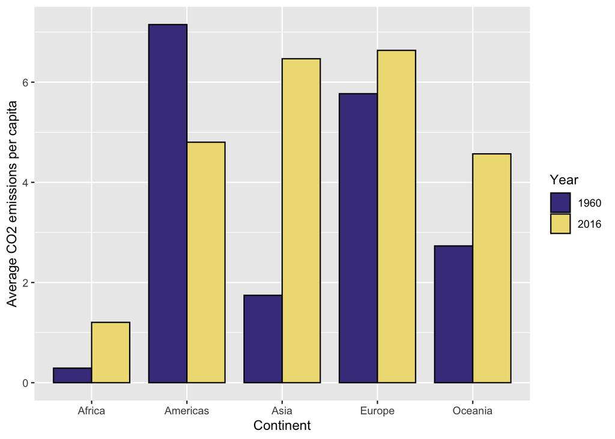

```r
avg_region_co2_PC_1960_2016 <- avg_region_co2_PC %>%
  filter(time == 1960 | time == 2016)

ggplot(avg_region_co2_PC_1960_2016, aes(x = region, y = co2_PC_mean, fill = as.factor(time))) +
  geom_bar(stat = "identity", color="black", position = position_dodge(width = 0.8), width = 0.8) +
  scale_fill_manual(values = c("darkslateblue", "lightgoldenrod"), name = "Year") +
  labs(x = "Continent", y = "Average CO2 emissions per capita",
       y = "Average CO2 per Capita")
```

6. Because 2019 data is missing, I’ll take 2016…

```r
# Calculate mean CO2 emissions per capita for each country in each continent for the year 2019
co2_per_capita_2016 <- df %>%
  filter(!is.na(region),
         time == 2016,
         !is.na(co2_PC)) %>%
  group_by(name) %>%
  summarize(region, name, mean_co2_PC = mean(co2_PC)) %>%
  arrange(region, desc(mean_co2_PC))

# Top 3 countries with highest mean co2_PC  for each region
co2_per_capita_2016 %>%
  group_by(region) %>%
  slice_max(mean_co2_PC, n = 3) %>%
  select(region, name, mean_co2_PC)
```

```
## # A tibble: 15 × 3
## # Groups:   region [5]
##    region   name                     mean_co2_PC
##    <chr>    <chr>                          <dbl>
##  1 Africa   South Africa                    8.48
##  2 Africa   Libya                           7.79
##  3 Africa   Seychelles                      6.39
##  4 Americas Trinidad and Tobago            31.8
##  5 Americas United States of America       15.5
##  6 Americas Canada                         15.1
##  7 Asia     Qatar                          38.9
##  8 Asia     Kuwait                         25.0
##  9 Asia     Bahrain                        22.2
## 10 Europe   Gibraltar                      18.8
## 11 Europe   Luxembourg                     15.4
## 12 Europe   Faroe Islands                  13.1
## 13 Oceania  New Caledonia                  19.3
## 14 Oceania  Australia                      15.5
## 15 Oceania  Palau                          12.6
```

```r
# Top 3 countries with lowest mean co2_PC for each region
co2_per_capita_2016 %>%
  group_by(region) %>%
  slice_min(mean_co2_PC, n = 3) %>%
  select(region, name, mean_co2_PC)
```

```
## # A tibble: 15 × 3
## # Groups:   region [5]
##    region   name                              mean_co2_PC
##    <chr>    <chr>                                   <dbl>
##  1 Africa   Congo, Democratic Republic of the      0.0256
##  2 Africa   Somalia                                0.0455
##  3 Africa   Burundi                                0.0472
##  4 Americas Haiti                                  0.275
##  5 Americas Nicaragua                              0.887
##  6 Americas Honduras                               1.06
##  7 Asia     Afghanistan                            0.245
##  8 Asia     Nepal                                  0.334
##  9 Asia     Yemen                                  0.390
## 10 Europe   Liechtenstein                          1.36
## 11 Europe   Albania                                1.58
## 12 Europe   Moldova, Republic of                   1.83
## 13 Oceania  Solomon Islands                        0.272
## 14 Oceania  Vanuatu                                0.527
## 15 Oceania  Kiribati                               0.587
```

# GDP per Capita

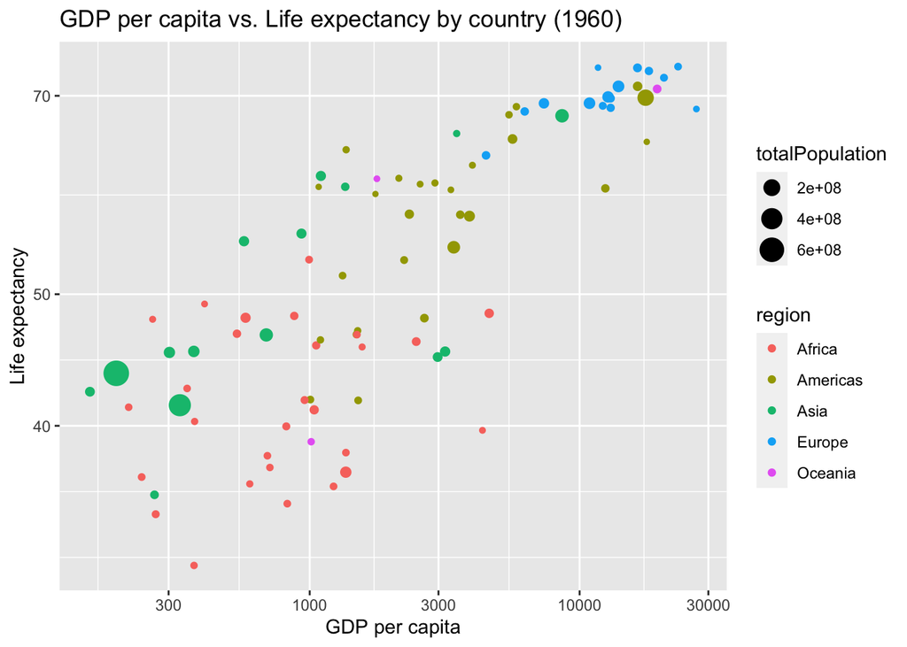

```r
# Filter data for 1960 and remove rows with missing data
df_1960 <- df %>%
  filter(time == 1960, !is.na(GDP_PC) & !is.na(lifeExpectancy))

# Create a ggplot scatterplot
ggplot(df_1960, aes(x = GDP_PC, y = lifeExpectancy)) +
  geom_point(aes(size = totalPopulation, color = region)) +
  scale_x_log10() +
  scale_y_log10() +
  labs(title = "GDP per capita vs. Life expectancy by country (1960)",
       x = "GDP per capita",
       y = "Life expectancy")
```

I see that in 1960, there is a trend where if a country’s GDP per capita tends toward 0, life expectancy logarithmically decreases to 0.

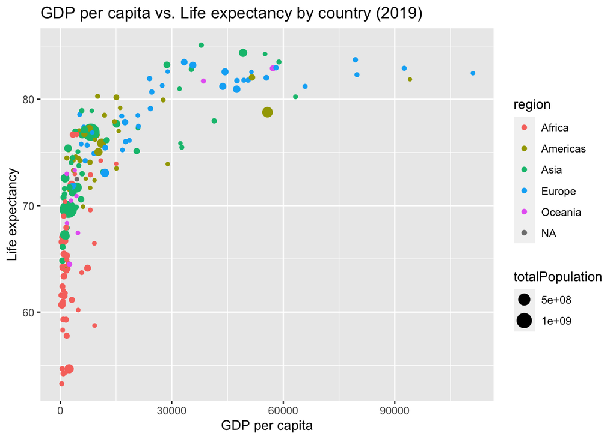

```r
# Filter data for 2019 and remove rows with missing data
df_1960 <- df %>%
  filter(time == 2019, !is.na(GDP_PC) & !is.na(lifeExpectancy))

# Create a ggplot scatterplot
ggplot(df_1960, aes(x = GDP_PC, y = lifeExpectancy)) +
  geom_point(aes(size = totalPopulation, color = region)) +
  labs(title = "GDP per capita vs. Life expectancy by country (2019)",
       x = "GDP per capita",
       y = "Life expectancy")
```

```r
avg_life_exp <- df %>%
  filter(time %in% c(1960, 2019), !is.na(lifeExpectancy)) %>%
  group_by(region, time) %>%
  summarize(mean_life_expectancy = mean(lifeExpectancy)) %>%
  arrange(region, time)
avg_life_exp
```

```
## # A tibble: 12 × 3
## # Groups:   region [6]
##    region    time mean_life_expectancy
##    <chr>    <dbl>                <dbl>
##  1 Africa    1960                 41.5
##  2 Africa    2019                 64.1
##  3 Americas  1960                 58.6
##  4 Americas  2019                 75.8
##  5 Asia      1960                 51.6
##  6 Asia      2019                 74.6
##  7 Europe    1960                 68.3
##  8 Europe    2019                 79.4
##  9 Oceania   1960                 56.4
## 10 Oceania   2019                 73.5
## 11 <NA>      1960                 70.7
## 12 <NA>      2019                 77.8
```

The figures themselves do not do much justice for each individual region as there are no trend lines, but the mean life expectancy difference between 1960 and 2019 for each continent is consistently growing.

```r
continent_avg_growth <- df %>%
  filter(!is.na(region), time %in% c(1960, 2019), !is.na(lifeExpectancy)) %>%
  group_by(region) %>%
  summarize(avg_growth = (mean(lifeExpectancy[time == 2019]) -
                            mean(lifeExpectancy[time == 1960]))/
                            mean(lifeExpectancy[time == 1960]) * 100) %>%
  arrange(region)

continent_avg_growth
```

```
## # A tibble: 5 × 2
##   region   avg_growth
##   <chr>         <dbl>
## 1 Africa         54.6
## 2 Americas       29.3
## 3 Asia           44.5
## 4 Europe         16.2
## 5 Oceania        30.4
```

I see that the average growth in the Europe is the least and Africa is the most.

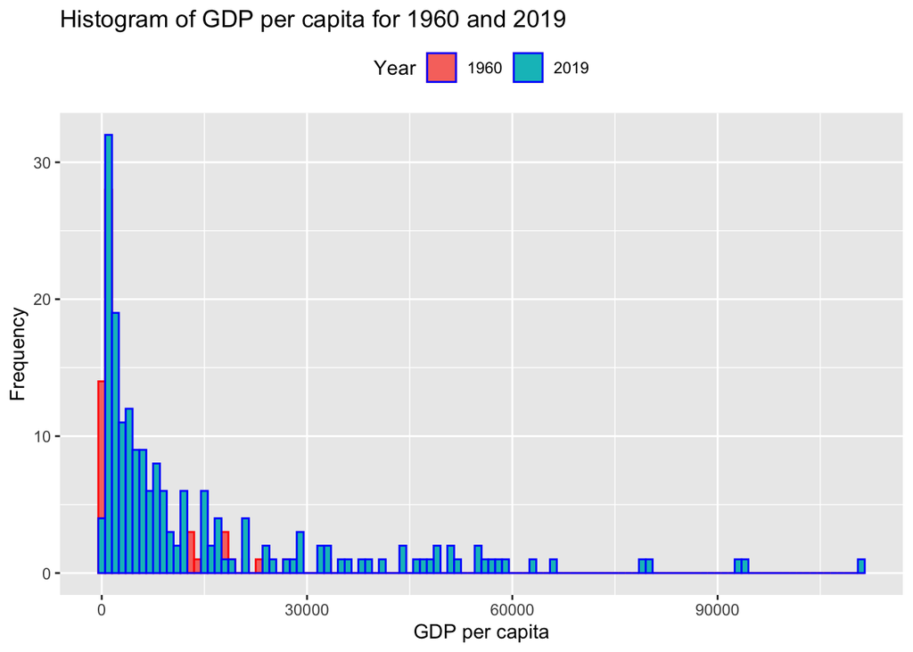

```r
df_1960_2019 <- df %>% filter(time %in% c(1960, 2019))

# Create separate data frames for 1960 and 2019
df_1960 <- df_1960_2019 %>% filter(time == 1960)
df_2019 <- df_1960_2019 %>% filter(time == 2019)

# Create a combined histogram using ggplot2
ggplot() +
  # Plot the 1960 data as a histogram in red
  geom_histogram(binwidth = 1000, data = df_1960, aes(x = GDP_PC, fill = "1960"), color = "red") +
  # Plot the 2019 data as a histogram in blue
  geom_histogram(binwidth = 1000, data = df_2019, aes(x = GDP_PC, fill = "2019"), color = "blue") +
  # Set the x-axis label
  xlab("GDP per capita") +
  # Set the y-axis label
  ylab("Frequency") +
  # Set the legend title
  labs(fill = "Year") +
  # Set the title of the plot
  ggtitle("Histogram of GDP per capita for 1960 and 2019") +
  # Adjust the legend position
  theme(legend.position = "top")
```

```r
# 1960
new_df <- df
new_df %>%
  filter(region != "World", time == 1960, !is.na(lifeExpectancy)) %>%
  arrange(desc(lifeExpectancy)) %>%
  mutate(rank = rank(-lifeExpectancy)) %>%
  filter(name == "United States of America") %>%
  select(rank)
```

```
## # A tibble: 1 × 1
##    rank
##   <dbl>
## 1    17
```

```r
# 2019
new_df <- df
new_df %>%
  filter(region != "World", time == 2019, !is.na(lifeExpectancy)) %>%
  arrange(desc(lifeExpectancy)) %>%
  mutate(rank = rank(-lifeExpectancy)) %>%
  filter(name == "United States of America") %>%
  select(rank)
```

```
## # A tibble: 1 × 1
##    rank
##   <dbl>
## 1    46
```

The US was 17th in 1960 and was 46th in 2019.

```r
# 1960
rank_1960 <- df %>%
  filter(region != "World", time == 1960, !is.na(lifeExpectancy)) %>%
  arrange(desc(lifeExpectancy)) %>%
  select(name, lifeExpectancy) %>%
  mutate(rank = rank(-lifeExpectancy)) %>%
  filter(name == "United States of America") %>%
  pull(rank)

n_1960 <- df %>%
  filter(time == 1960, !is.na(lifeExpectancy)) %>%
  count()

rel_rank_1960 <- rank_1960 / (n_1960$n - 1)
rel_rank_1960
```

```
## [1] 0.09042553
```

```r
# 2019
rank_2019 <- df %>%
  filter(region != "World", time == 2019, !is.na(lifeExpectancy)) %>%
  arrange(desc(lifeExpectancy)) %>%
  select(name, lifeExpectancy) %>%
  mutate(rank = rank(-lifeExpectancy)) %>%
  filter(name == "United States of America") %>%
  pull(rank)

n_2019 <- df %>%
  filter(time == 2019, !is.na(lifeExpectancy)) %>%
  count()

rel_rank_2019 <- rank_2019 / (n_2019$n - 1)
rel_rank_2019
```

```
## [1] 0.2335025
```

### Finally

This problem set took me 6 hours uninterrupted, about 14 hours interrupted.